# Final Exam Part 2

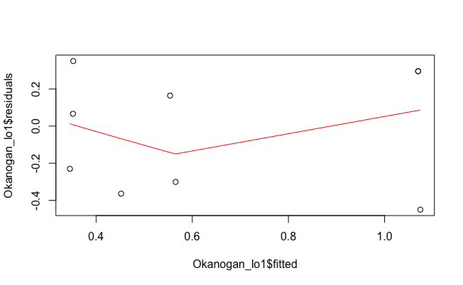

```r
# residual scatter diagram of loess model 1
plot(Okanogan_lo1$fitted, Okanogan_lo1$residuals)
lines(lowess(Okanogan_lo1$fitted, Okanogan_lo1$residuals, f=0.80), col="red")
```

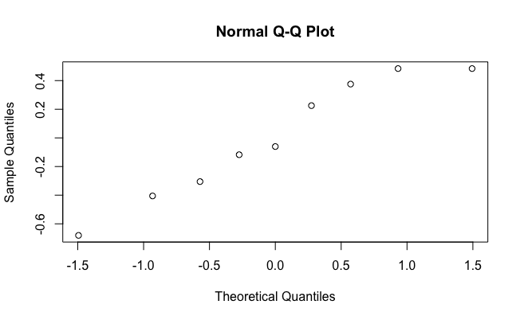

```r
# Inspect qq plots.
qqnorm(Okanogan_lm1$residuals)
```

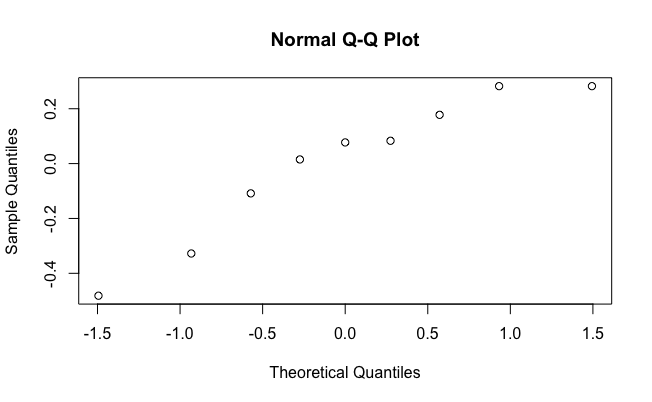

```r
qqnorm(Okanogan_lm2$residuals)
```

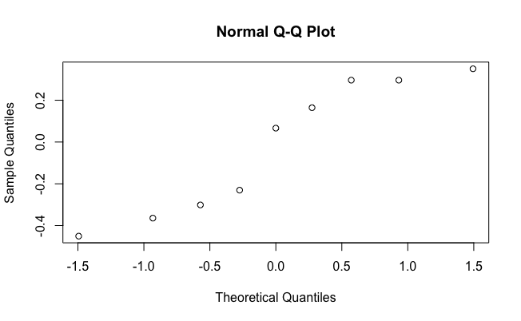

```r
qqnorm(Okanogan_lo1$residuals)
```

```r
summary(Okanogan_lm1)
```

```
Call:
lm(formula = Okanogan_INFO_omit$mean_Q ~ Okanogan_INFO_omit$drainSqKm)

Residuals:
     Min       1Q   Median       3Q      Max
-0.68070 -0.30518 -0.06035  0.37569  0.48399

Coefficients:
                             Estimate Std. Error t value Pr(>|t|)
(Intercept)                  0.164718   0.348136   0.473    0.651
Okanogan_INFO_omit$drainSqKm 0.001871   0.001268   1.476    0.183

Residual standard error: 0.447 on 7 degrees of freedom
Multiple R-squared:  0.2374,    Adjusted R-squared:  0.1284
F-statistic: 2.179 on 1 and 7 DF,  p-value: 0.1834
```

```r
summary(Okanogan_lm2)
```

```
Call:
lm(formula = Okanogan_INFO_omit$mean_Q ~ Okanogan_INFO_omit$drainSqKm +
    Okanogan_INFO_omit$dec_lat_va + Okanogan_INFO_omit$dec_long_va)

Residuals:
       1        2        3        4        5        6        7        8        9
 0.01510 -0.48163  0.28238 -0.32774  0.28238  0.17775  0.08318  0.07717 -0.10858

Coefficients:
                                 Estimate Std. Error t value Pr(>|t|)
(Intercept)                    -2.363e+02  1.621e+02  -1.457   0.2048
Okanogan_INFO_omit$drainSqKm    2.495e-03  1.237e-03   2.018   0.0996 .
Okanogan_INFO_omit$dec_lat_va  -1.850e-01  7.778e-01  -0.238   0.8214
Okanogan_INFO_omit$dec_long_va -2.051e+00  1.118e+00  -1.835   0.1260
---
Signif. codes:  0 ‘***’ 0.001 ‘**’ 0.01 ‘*’ 0.05 ‘.’ 0.1 ‘ ’ 1

Residual standard error: 0.3333 on 5 degrees of freedom
Multiple R-squared:  0.6972,    Adjusted R-squared:  0.5155
F-statistic: 3.837 on 3 and 5 DF,  p-value: 0.09092
```

```r
summary(Okanogan_lo1)
```

```
Call:
loess(formula = Okanogan_INFO_omit$mean_Q ~ Okanogan_INFO_omit$drainSqKm,
    span = 0.8, degree = 2)

Number of Observations: 9
Equivalent Number of Parameters: 3.63
Residual Standard Error: 0.4162
Trace of smoother matrix: 3.98  (exact)

Control settings:
  span     :  0.8
  degree   :  2
  family   :  gaussian
  surface  :  interpolate     cell = 0.2
  normalize:  TRUE
 parametric:  FALSE
drop.square:  FALSE
```

As far as the best regression model, the first linear regression with the outlier data removed had the most diagonally linear QQ plot. Furthermore, the residual scatter plot was the most flat, although still not perfect. However, its p values were not statistically significant and its R-squared was incredibly low.

This means that, the discharge area is not a predictor or part of the regression equation for discharge rate, and that other variables need to be included in the equation. In the future, it would be interesting to consider other variables such as average precipitation and temperature and river depth.

> > Static Map

Then I created a Ggplot static map of the stations colored by their Drainage area, and demonstrating where in Washington state the river basin is located.

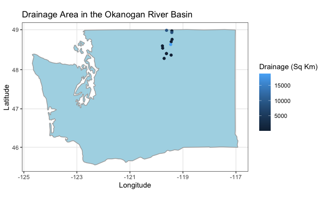

```r
# Static map of Drainage area at each station
wa_map <- map_data("state", region = "washington")
wa_map_sf <- st_as_sf(wa_map, coords = c("long", "lat"))

ggplot() +
  geom_polygon(data = wa_map, aes(x = long, y = lat, group = group), fill = "lightblue", color = "darkgrey") +
  geom_point(aes(Okanogan_rb_INFO$dec_long_va, Okanogan_rb_INFO$dec_lat_va, color = Okanogan_rb_INFO$drainSqKm)) +
  coord_equal() +
  scale_color_continuous("Drainage (Sq Km)") +
  scale_x_continuous("Longitude") +
  scale_y_continuous("Latitude") +
  coord_map(projection="mercator") +
  labs(title = "Drainage Area in the Okanogan River Basin ") +
  theme_bw()
```

> > Interactive Map

As well as an interactive map using the leaflet library where users can zoom in and out of the data.

```r
# Interactive map of all of the USGS stations
# Transform data frame into sf
qmean <- st_as_sf(Okanogan_rb_INFO, coords = c("dec_long_va", "dec_lat_va"))

# Leaflet map
m <- leaflet() %>%
  addTiles() %>%
  addCircleMarkers(data = qmean,
                   radius = 1,
                   fillOpacity = 3,
                   fillColor = "#00558e") %>%
  addControl(
    position = "topright",
    html = "<h4>Okanagan River Basin USGS Stations</h4>"
  )
m
```

[interactive chart not shown]

> > Conclusion

The USGS Water monitoring stations in the Okanagan River Basin demonstrate diversity when it comes to drainage areas and drainage rates. Understanding this information is useful for flood management and response, as well as water supply.

A future study should analyze other factors that might play a role in these variables, and should also consider locations in this basin that are located in Canada. There are several factors that would be interesting to explore including elevation, precipitation, and temperature data. Some of this information could be accessed by defining other parameters in the EGRET package. Including these variables might make a future regression analyze more valuable.

It would also be interesting to translate this study to a different river basin with more stations to see if that could increase noticeable patterns.